# Visualizing Categorical by Categorical Data

Using Data From The Titanic

Andy Grogan-Kaylor

2020-09-19

# 1 Background

The R software contains data on the Titanic disaster. We will use different visualization ideas, and this data, to explore factors that may have contributed to surviving the Titanic disaster.

> We are going to explore–in particular–the question of whether social class was associated with surviving the Titanic disaster.

# 2 Setup

```r
library(datasets) # datasets

library(dplyr) # data wrangling

library(tidyr) # data tidying

library(ggplot2) # beautiful graphs

library(ggmosaic) # mosaic plots

library(ggalluvial) # alluvial diagrams

library(ggthemes) # beautiful themes

library(waffle) # waffle plots

library(patchwork) # arrange plots

library(pander) # nice tables

library(DT) # interactive tables
```

# 3 Titanic Data

```r
data("Titanic")

Titanic_data <- as.data.frame(Titanic)

Titanic_data <- Titanic_data %>%
  uncount(Freq) # expand
```

## 3.1 Summary Table

```r
Titanic_data %>%
  group_by(Class, Survived) %>%
  tally() %>%
  datatable()
```

|  | Class | Survived | n |
| --- | --- | --- | --- |
| 1 | 1st | No | 122 |
| 2 | 1st | Yes | 203 |
| 3 | 2nd | No | 167 |
| 4 | 2nd | Yes | 118 |
| 5 | 3rd | No | 528 |
| 6 | 3rd | Yes | 178 |
| 7 | Crew | No | 673 |
| 8 | Crew | Yes | 212 |

## 3.2 All Rows of Data

```r
datatable(Titanic_data)
```

|  | Class | Sex | Age | Survived |
| --- | --- | --- | --- | --- |
| 3 | 3rd | Male | Child | No |
| 3.1 | 3rd | Male | Child | No |
| 3.2 | 3rd | Male | Child | No |
| 3.3 | 3rd | Male | Child | No |
| 3.4 | 3rd | Male | Child | No |
| 3.5 | 3rd | Male | Child | No |
| 3.6 | 3rd | Male | Child | No |
| 3.7 | 3rd | Male | Child | No |
| 3.8 | 3rd | Male | Child | No |
| 3.9 | 3rd | Male | Child | No |

[output cut: 2191 more lines]

## 3.3 CrossTabulation

```r
gmodels::CrossTable(Titanic_data$Class, Titanic_data$Survived)
```

```
##
##
##    Cell Contents
## |-------------------------|
## |                       N |
## | Chi-square contribution |
## |           N / Row Total |
## |           N / Col Total |
## |         N / Table Total |
## |-------------------------|
##
##
## Total Observations in Table:  2201
##
##
##                    | Titanic_data$Survived
## Titanic_data$Class |        No |       Yes | Row Total |
## -------------------|-----------|-----------|-----------|
##                1st |       122 |       203 |       325 |
##                    |    43.664 |    91.504 |           |
##                    |     0.375 |     0.625 |     0.148 |
##                    |     0.082 |     0.286 |           |
##                    |     0.055 |     0.092 |           |
## -------------------|-----------|-----------|-----------|
##                2nd |       167 |       118 |       285 |
##                    |     3.486 |     7.306 |           |
##                    |     0.586 |     0.414 |     0.129 |
##                    |     0.112 |     0.166 |           |
##                    |     0.076 |     0.054 |           |
## -------------------|-----------|-----------|-----------|
##                3rd |       528 |       178 |       706 |
##                    |     5.244 |    10.989 |           |
##                    |     0.748 |     0.252 |     0.321 |
##                    |     0.354 |     0.250 |           |
##                    |     0.240 |     0.081 |           |
## -------------------|-----------|-----------|-----------|
##               Crew |       673 |       212 |       885 |
##                    |     9.112 |    19.095 |           |
##                    |     0.760 |     0.240 |     0.402 |
##                    |     0.452 |     0.298 |           |
##                    |     0.306 |     0.096 |           |
## -------------------|-----------|-----------|-----------|
##       Column Total |      1490 |       711 |      2201 |
##                    |     0.677 |     0.323 |           |
## -------------------|-----------|-----------|-----------|
##
##
```

```r
# table(Titanic_data$Class, Titanic_data$Survived)

chisq.test(table(Titanic_data$Class, Titanic_data$Survived))
```

```
##
##  Pearson's Chi-squared test
##
## data:  table(Titanic_data$Class, Titanic_data$Survived)
## X-squared = 190.4, df = 3, p-value < 2.2e-16
```

# 4 Mosaic Plot

> Order matters in a mosaic plot because we are always conditioning on one variable.

> Phrased in terms of [Bayes Theorem](https://agrogan1.github.io/Bayes/Bayes-Theorem/Bayes-Theorem.html), $P(A|B) \neq P(B|A)$.

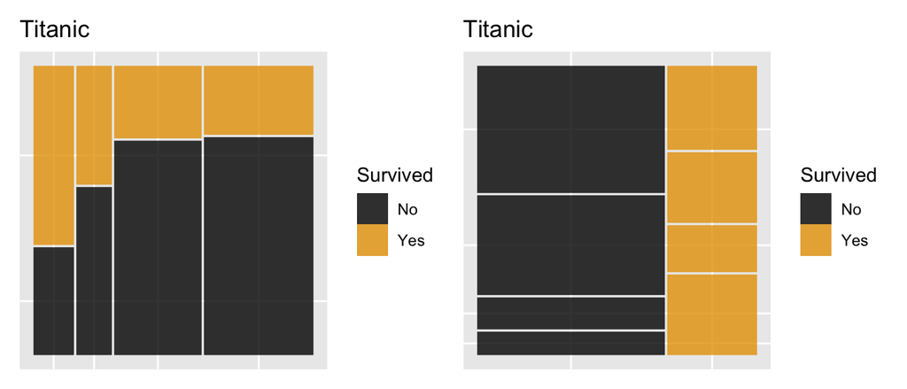

```r
p1A <- ggplot(Titanic_data) +
  geom_mosaic(aes(x = product(Survived, # mosaic is Survived X Class
                              Class),
                  fill = Survived), # fill is Survived
              na.rm=TRUE) +
  labs(title = "Titanic") +
  scale_fill_colorblind() +
  theme(axis.title = element_blank())

p1B <- ggplot(Titanic_data) +
   geom_mosaic(aes(x = product(Class, # mosaic is Class X Survived
                               Survived),
                  fill = Survived), # fill by Survived
               na.rm=TRUE) +
  labs(title = "Titanic") +
  scale_fill_colorblind() +
  theme(axis.title = element_blank())

p1A + p1B + plot_layout(ncol = 2)
```

## 4.1 Statistical Independence or Dependence

> How do we assess statistical independence or statistical dependence in a mosaic plot?

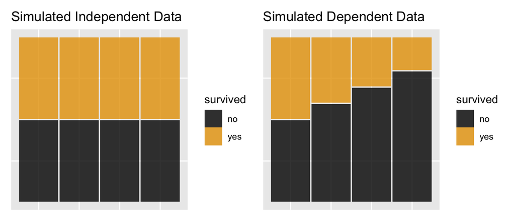

```r
class <- c("1st", "1st",
           "2nd", "2nd",
           "3rd", "3rd",
           "Crew", "Crew")

survived <- c("yes", "no",
              "yes", "no",
              "yes", "no",
              "yes", "no")

independent_counts <- rep(10, 8)

dependent_counts <- c(5, 5,
                      4, 6,
                      3, 7,
                      2, 8)

simulated_data <- tibble(class,
                         survived,
                         independent_counts,
                         dependent_counts)

independent_data <- simulated_data %>%
  uncount(independent_counts)

dependent_data <- simulated_data %>%
  uncount(dependent_counts)

s1A <- ggplot(independent_data) +
  geom_mosaic(aes(x = product(survived, class),
                  fill = survived)) +
  scale_fill_colorblind() +
  theme(axis.title = element_blank()) +
  labs(title = "Simulated Independent Data")

s2A <- ggplot(dependent_data) +
  geom_mosaic(aes(x = product(survived, class),
                  fill = survived)) +
  scale_fill_colorblind() +
  theme(axis.title = element_blank()) +
  labs(title = "Simulated Dependent Data")

s1A + s2A
```

# 5 Bar Chart

> Order also matters in a bar chart because we are again conditioning on one variable.

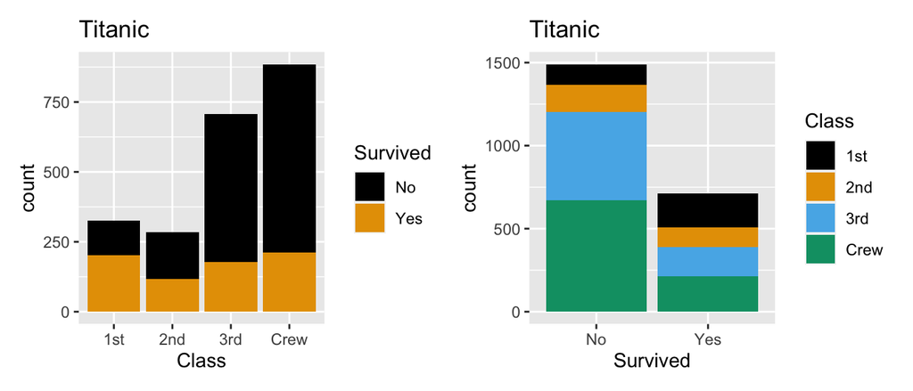

```r
p2A <- ggplot(Titanic_data,
       aes(x = Class, # x is Class
           fill = Survived)) + # fill is Survived
  geom_bar() +
  labs(title = "Titanic") +
  scale_fill_colorblind()

p2B <- ggplot(Titanic_data,
       aes(x = Survived, # x is Survived
           fill = Class)) + # fill is Class
  geom_bar() +
  labs(title = "Titanic") +
  scale_fill_colorblind()

p2A + p2B
```

> Do we assess statistical independence or statistical dependence in the same way?

# 6 Stacked Bar Chart

> A stacked bar chart may clarify the percentages within each bar, but may obscure the fact that each bar represents different numbers of people.

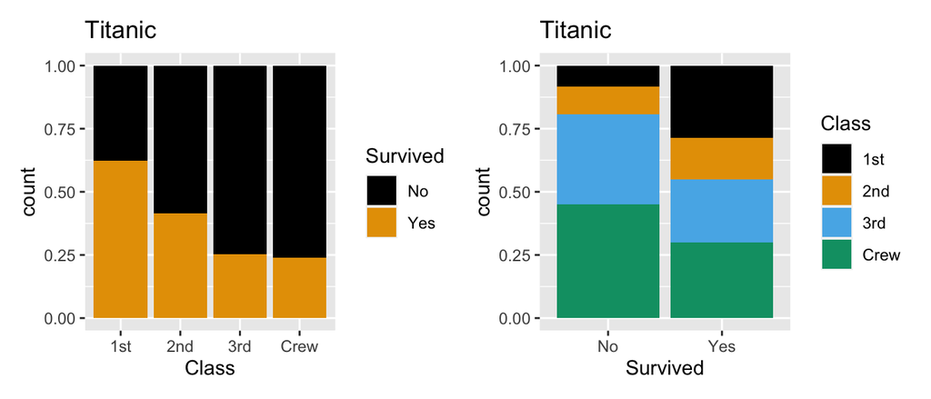

```r
p3A <- ggplot(Titanic_data,
       aes(x = Class, # x is Class
           fill = Survived)) + # fill is Survived
  geom_bar(position = "fill") +
  labs(title = "Titanic") +
  scale_fill_colorblind()

p3B <- ggplot(Titanic_data,
       aes(x = Survived, # x is Survived
           fill = Class)) + # fill is Class
  geom_bar(position = "fill") +
  labs(title = "Titanic") +
  scale_fill_colorblind()

p3A + p3B
```

> Do we assess statistical independence or statistical dependence in the same way?

# 7 Waffle Chart

> Like many of the visualization techniques explored so far, waffle plots depend crucially on the ordering of variables.

> Waffle charts may work better with smaller data sets, and less well with larger data sets such as the data that we are using in this example.

> The origins of the Waffle Chart are likely multiple, but one line of thinking can be traced back to the work of Marie Neurath.

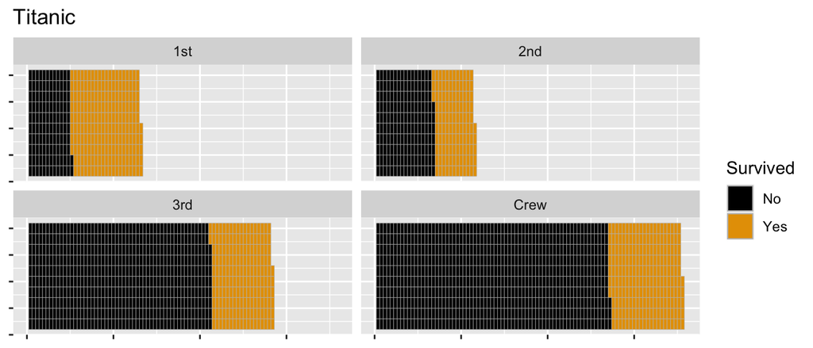

```r
# waffle charts require some data wrangling

p4A <- Titanic_data %>%
  group_by(Class, Survived) %>% # group by Class X Survived
  tally() %>% # count up; count = n
  ggplot(aes(fill = Survived, # fill by Survived
             values = n)) + # values are n (count)
  geom_waffle(color = "grey") +
  labs(title = "Titanic") +
  scale_fill_colorblind() +
  facet_wrap(~Class) + # facet on Class
  theme(axis.text = element_blank())

p4B <- Titanic_data %>%
  group_by(Class, Survived) %>% # group by Class X Survived
  tally() %>% # count up; count = n
  ggplot(aes(fill = Class, # fill by Class
             values = n)) + # values are n (count)
  geom_waffle(color = "grey") +
  labs(title = "Titanic") +
  scale_fill_colorblind() +
  facet_wrap(~Survived) + # facet on Survived
  theme(axis.text = element_blank())

p4A # replay
```

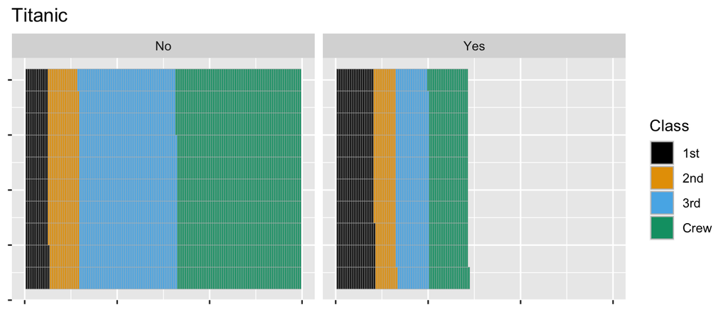

```r
p4B # replay
```

> Do we assess statistical independence or statistical dependence in the same way?

# 8 Scatterplot

A scatterplot is an older style of visualizing categorical data, and arguably works less well than some other methods.

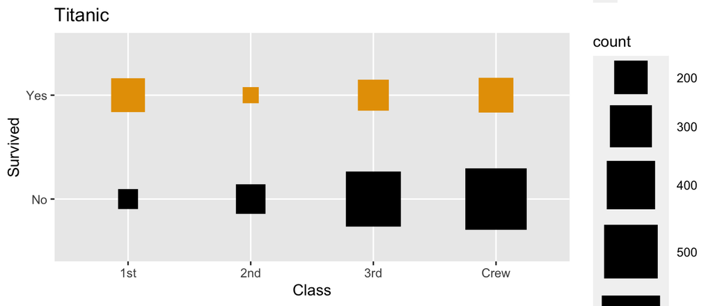

```r
p5A <- Titanic_data %>%
  group_by(Class, Survived) %>% # group by Class X Survived
  tally() %>% # count up; count = n
  ggplot(aes(x = Class, # x is Class
             y = Survived, # y is Survived
             color = Survived, # color is Survived
             size = n)) + # size of points is n (count)
  geom_point(shape = 15) + # square
  labs(title = "Titanic") +
  scale_size_continuous(range = c(5, 20),
                        name = "count") +
  scale_color_colorblind()

p5A
```

> How do we assess statistical independence or statistical dependence with a scatterplot?

# 9 Heatmap

A Heatmap is a more recent form of data visualization and has the advantage of somewhat looking like a cross-tabulation.

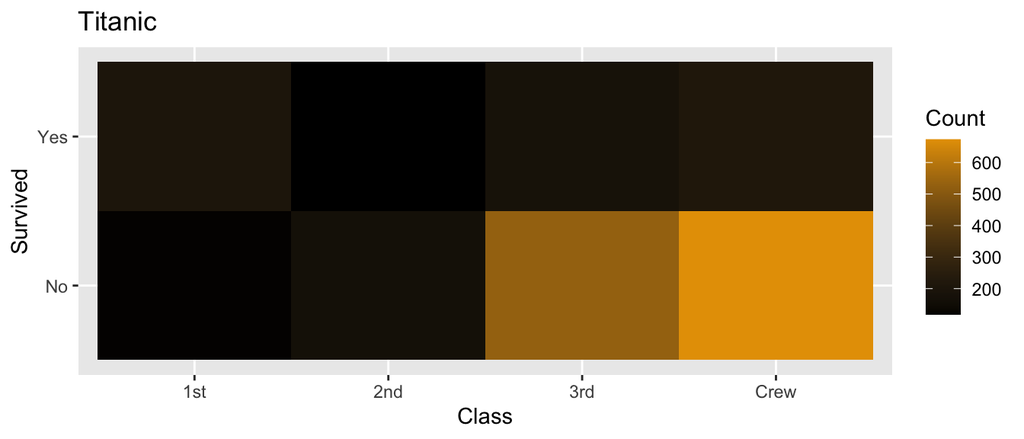

```r
p6A <- Titanic_data %>%
  group_by(Class, Survived) %>% # group by Class X Survived
  tally() %>% # count up; count = n
  ggplot(aes(x = Class, # x is Class
             y = Survived, # y is Survived
             fill = n)) + # fill is n (count)
  geom_tile() +
  labs(title = "Titanic") +
  scale_fill_gradient(name = "Count",
                      low = "#000000",
                      high = "#E69F00")

p6A
```

> How do we assess statistical independence or statistical dependence with a heatmap?

# 10 Alluvial Diagram

Alluvial diagrams (closely related to Sankey diagrams) have become more prominent more recently, but have a long history, tracing back to the famous [Minard diagram](https://en.wikipedia.org/wiki/Charles_Joseph_Minard#The_map_of_Napoleon's_Russian_campaign).

```r
knitr::include_graphics("Minard.png")
```

[output not shown]

One inspiration for alluvial diagrams has been to track changes in large networks over time (Rosvall and Bergstrom 2010), but they can also be useful in visualizing categorical data.

> Code below is adapted from http://corybrunson.github.io/ggalluvial/.

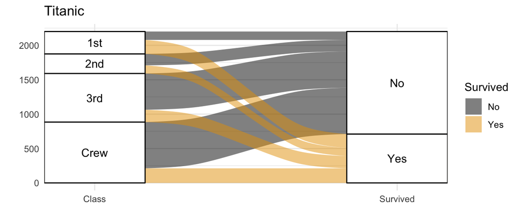

```r
p7A <- Titanic_data %>%
  group_by(Class, Survived) %>% # group by Class X Survived
  tally() %>% # count up; count is n
  ggplot(aes(axis1 = Class, # axes
             axis2 = Survived,
             y = n)) +
  geom_alluvium(aes(fill = Survived)) + # alluvium geom (Survived)
  geom_stratum() +
  geom_text(stat = "stratum",
            aes(label = after_stat(stratum))) +
  scale_x_discrete(limits = c("Class", "Survived"),
                   expand = c(.1, .05)) +
  scale_fill_colorblind() +
  xlab("") +
  ylab("") +
  theme_minimal() +
  labs(title = "Titanic")

p7A
```

> How do we assess statistical independence or statistical dependence with an alluvial diagram?

# 11 Simpson’s Paradox

Simpson’s Paradox is the idea that observed associations may change when a new variable is added.

> Do the visualizations below present evidence that Simpson’s paradox is at work in the Titanic data?

> Which of these visualizations best conveys the idea of Simpson’s paradox?

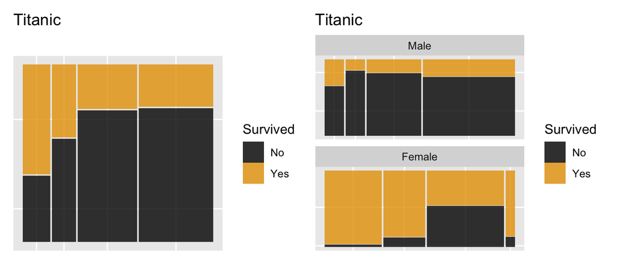

```r
p1A | p1A + facet_wrap(~Sex, nrow = 2, scales = "free")
```

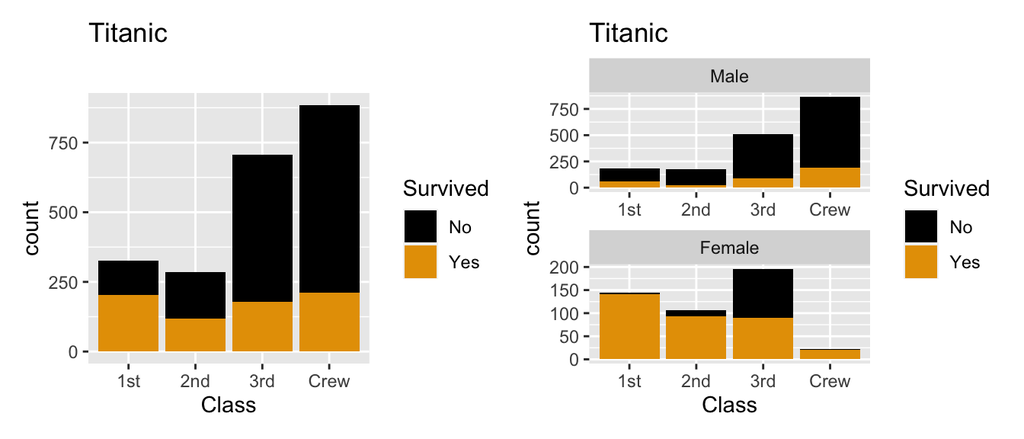

```r
p2A | p2A + facet_wrap(~Sex, nrow = 2, scales = "free")
```

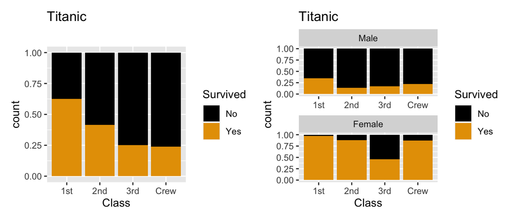

```r
p3A | p3A + facet_wrap(~Sex, nrow = 2, scales = "free")
```

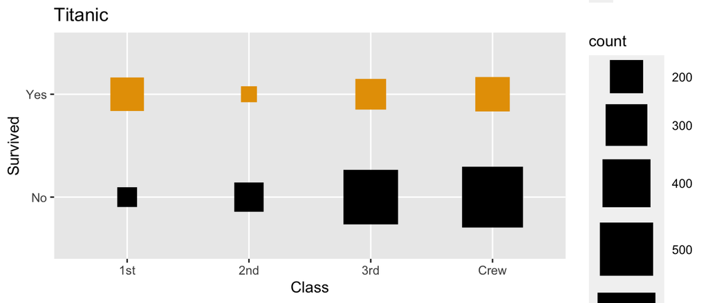

```r
p5Afacet <- Titanic_data %>%
  group_by(Class, Survived, Sex) %>%
  tally() %>%
  ggplot(aes(x = Class,
             y = Survived,
             color = Survived,
             size = n)) +
  geom_point(shape = 15) + # square
  labs(title = "Titanic") +
  # scale_size_continuous(range = c(5, 20),
  #                       name = "count") +
  scale_color_colorblind() +
  facet_wrap(~Sex, ncol = 1)

p5A
```

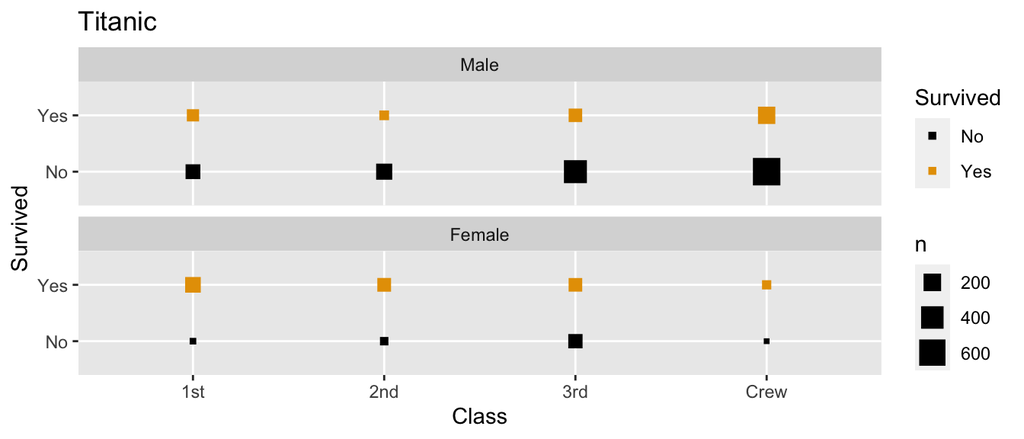

```r
p5Afacet
```

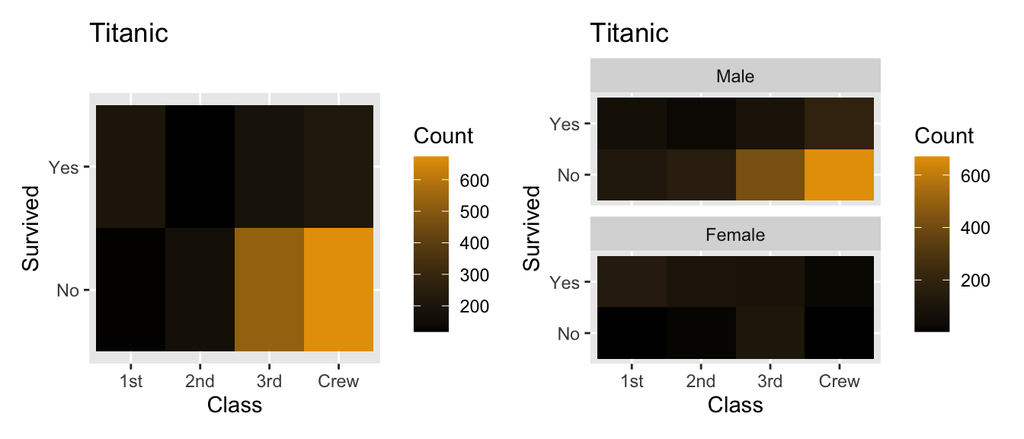

```r
p6Afacet <- Titanic_data %>%
  group_by(Class, Survived, Sex) %>%
  tally() %>%
  ggplot(aes(x = Class, y = Survived, fill = n)) +
  geom_tile() +
  labs(title = "Titanic") +
  scale_fill_gradient(name = "Count",
                      low = "#000000",
                      high = "#E69F00") +
  facet_wrap(~Sex, nrow = 2)

p6A + p6Afacet
```

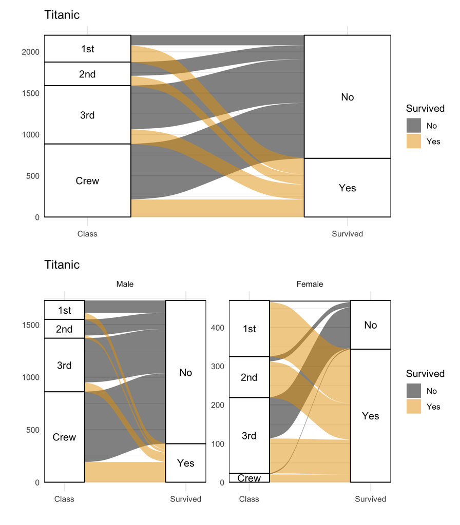

```r
p7Afacet <- Titanic_data %>%
  group_by(Class,
           Survived,
           Sex) %>% # group by Class, Sex and Survived
  tally() %>% # count up
  ggplot(aes(axis1 = Class,
             axis2 = Survived,
             y = n)) +
  geom_alluvium(aes(fill = Survived)) +
  geom_stratum() +
  geom_text(stat = "stratum",
            aes(label = after_stat(stratum))) +
  scale_x_discrete(limits = c("Class", "Survived"),
                   expand = c(.1, .05)) +
  scale_fill_colorblind() +
  xlab("") +
  ylab("") +
  theme_minimal() +
  labs(title = "Titanic") +
  facet_wrap(~Sex,
             scales = "free",
             nrow = 1)

p7A / p7Afacet
```

# References

Rosvall, Martin, and Carl T. Bergstrom. 2010. “Mapping change in large networks.” *PLoS ONE*. https://doi.org/10.1371/journal.pone.0008694.